# STAT 240 Discussion 3

## Group 6

**Remember**: you MUST complete this discussion in your assigned groups! If you are not able to be present, please try to join your group over Zoom (links provided in Canvas).

## Members Present

- Reena Singhal, **Kai Tsuyoshi**, Fei Qin, Jiahua Pan

## Members Absent

Malavika Unnikrishnan

## Questions

### 1

The code below modifies the exoplanet data table, `planets`. Review the code and then answer the question below the code chunk. Some questions will require additional code to answer them.

```r
planets = read_csv("../../data/exoplanets_default_2021-06-15.csv",
                   skip = 100) %>%
  select(pl_name, hostname, discoverymethod, disc_year, sy_pnum, pl_rade, pl_bmasse) %>%
  rename(planet = pl_name,
         star = hostname,
         method = discoverymethod,
         year = disc_year,
         number = sy_pnum,
         radius = pl_rade,
         mass = pl_bmasse)

planets %>%
  filter(year %in% c(2000,2005,2010,2015)) %>%
  count(method)
```

```
## # A tibble: 5 × 2
##   method                        n
##   <chr>                     <int>
## 1 Eclipse Timing Variations     3
## 2 Imaging                      12
## 3 Microlensing                  8
## 4 Radial Velocity             137
## 5 Transit                     146
```

> 1. What does the `skip = 100` argument to `read_csv()` do? Why is it necessary?

Skips the first 100 rows due to NA values which throw off calculations

> 2. What does the `rename()` function do to the data frame?

renames column names to better variable names that are easier to read

> 3. After running the code chunk, how many observations are in the data set?

4401

> 4. What are the combined number of exoplanets discovered in each of the years 2000, 2005, 2010, and 2015?

306

**For the remaining questions, use the `planets` data from Question 1.**

### 2

> Which methods are most commonly used to discover exoplanets?
- Create a bar graph that has the methods of exoplanet discovery on the x axis and counts of the number of planets discovered by each on the y axis.
- Give the graph a title and choose appropriate axis labels.
- The default graph might not have room to fit the tick labels without overwriting.
  - Use the function `theme()` to add a layer to the plot to rotate the axis labels
  - Try adding `theme( axis.text.x = element_text(angle=45, hjust=1) )` to the base plot
    - the `angle=45` argument rotates the labels by 45 degrees
    - the `hjust=1` argument justifies the end of each label at the same location

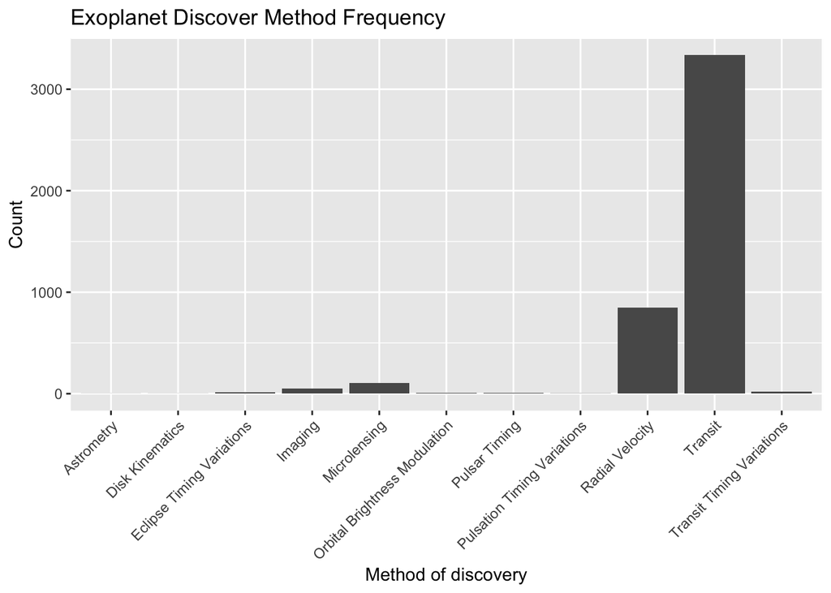

```r
ggplot(data= planets) +
  geom_bar(mapping=aes(x=method)) +
  theme (axis.text.x = element_text(angle = 45, hjust = 1)) +
  xlab("Method of discovery")+
  ylab("Count")+
  ggtitle("Exoplanet Discover Method Frequency")
```

### 3

> Create a summary data frame with one row for each method which counts the number of planets disovered by that method. Arrange the rows from most to least planets discovered. There will be a column for method and a column for the counts.

```r
summary = planets %>%
  select (method, number) %>%
  group_by(method) %>%
  summarize(total= sum(number)) %>%
  arrange(desc(total))
summary
```

```
## # A tibble: 11 × 2
##    method                        total
##    <chr>                         <dbl>
##  1 Transit                        6007
##  2 Radial Velocity                1550
##  3 Microlensing                    116
##  4 Imaging                          72
##  5 Transit Timing Variations        57
##  6 Eclipse Timing Variations        24
##  7 Orbital Brightness Modulation    14
##  8 Pulsar Timing                    13
##  9 Pulsation Timing Variations       2
## 10 Astrometry                        1
## 11 Disk Kinematics                   1
```

### 4

> Create a data set with one row per star and a column for the number of planets found by each star. Arrange the rows from the most to the least. How many stars are there in the data set? Which star has the most discovered exoplanets and how many are there?

```r
stars = planets %>%
  select(star, number) %>%
  group_by(star) %>%
  summarize(total = sum(number)) %>%
  arrange(desc(total))
stars
```

```
## # A tibble: 3,271 × 2
##    star       total
##    <chr>      <dbl>
##  1 KOI-351       64
##  2 TRAPPIST-1    49
##  3 HD 10180      36
##  4 HD 219134     36
##  5 HD 34445      36
##  6 K2-138        36
##  7 Kepler-11     36
##  8 Kepler-20     36
##  9 Kepler-80     36
## 10 TOI-178       36
## # … with 3,261 more rows
```

3271 Stars

### 5

> What are the mean and median number of confirmed exoplanets around each star in this data base?
- Note: sometimes when using the `group_by()` command, the grouping persists. - You can remove unwanted grouping with the `ungroup()` command.

```r
stars = planets %>%
  select(star, number) %>%
  group_by(star) %>%
  summarize(total = sum(number)) %>%
  arrange(mean(total))
stars
```

```
## # A tibble: 3,271 × 2
##    star                      total
##    <chr>                     <dbl>
##  1 11 Com                        1
##  2 11 UMi                        1
##  3 14 And                        1
##  4 14 Her                        1
##  5 16 Cyg B                      1
##  6 18 Del                        1
##  7 1RXS J160929.1-210524         1
##  8 24 Boo                        1
##  9 24 Sex                        4
## 10 2MASS J01033563-5515561 A     1
## # … with 3,261 more rows
```

```r
stars = planets %>%
  select(star, number) %>%
  group_by(star) %>%
  summarize(total = sum(number)) %>%
  arrange(median(total))
stars
```

```
## # A tibble: 3,271 × 2
##    star                      total
##    <chr>                     <dbl>
##  1 11 Com                        1
##  2 11 UMi                        1
##  3 14 And                        1
##  4 14 Her                        1
##  5 16 Cyg B                      1
##  6 18 Del                        1
##  7 1RXS J160929.1-210524         1
##  8 24 Boo                        1
##  9 24 Sex                        4
## 10 2MASS J01033563-5515561 A     1
## # … with 3,261 more rows
```